# Colorectal Cancer Incidence: A Global Comparison of Men and Women in 2020

Data Analysis Report 2025-10-22

## Introduction

This report examines the global distribution and relationship between colorectal cancer incidence rates in men and women during 2020. Colorectal cancer is one of the most common cancers worldwide, and understanding gender-specific patterns can inform public health strategies.

## Global Distribution of Colorectal Cancer in Men (2020)

The following map shows the incidence of colorectal cancer per 100,000 men across different countries in 2020.

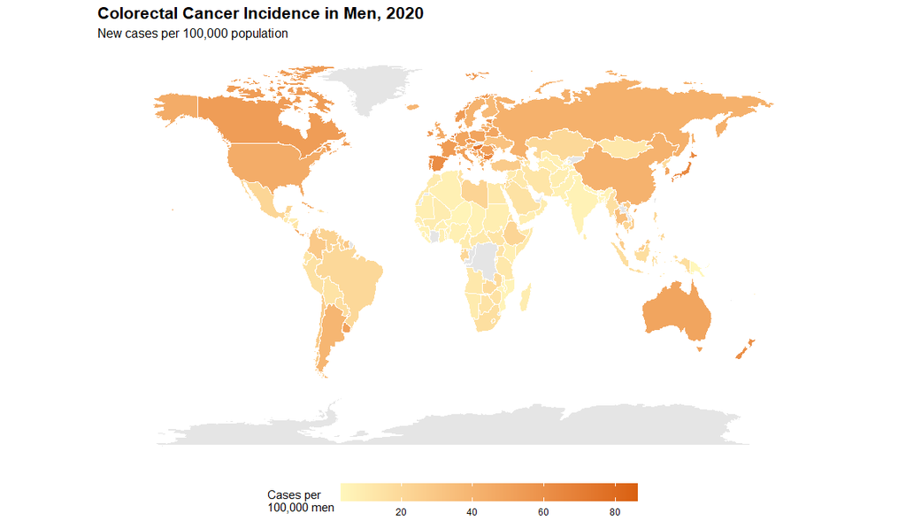

## Global Distribution of Colorectal Cancer in Women (2020)

The following map shows the incidence of colorectal cancer per 100,000 women across different countries in 2020.

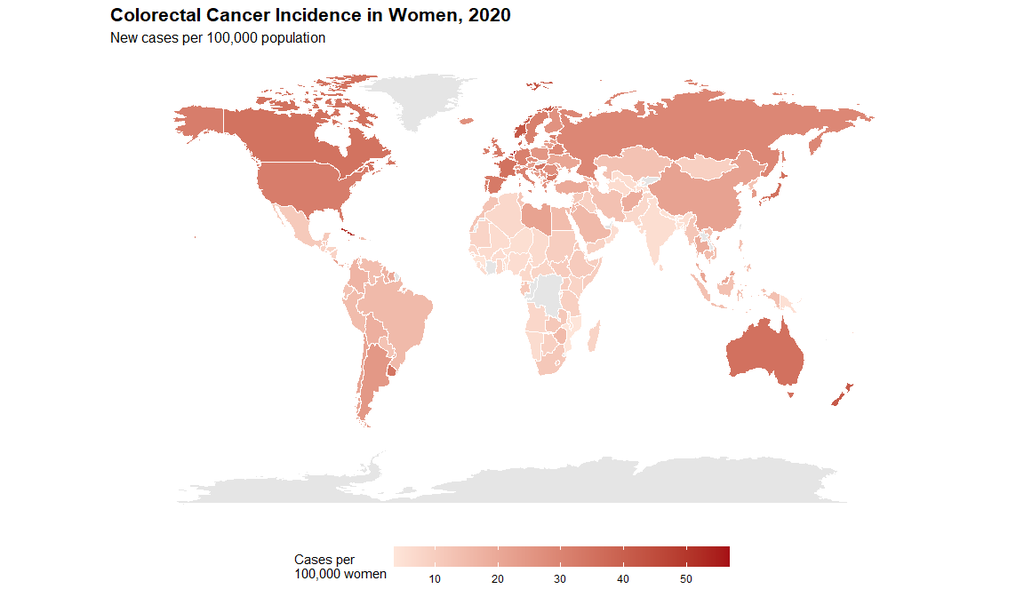

## Relationship Between Male and Female Incidence Rates

The scatterplot below illustrates the relationship between colorectal cancer incidence rates in men and women across all countries in 2020.

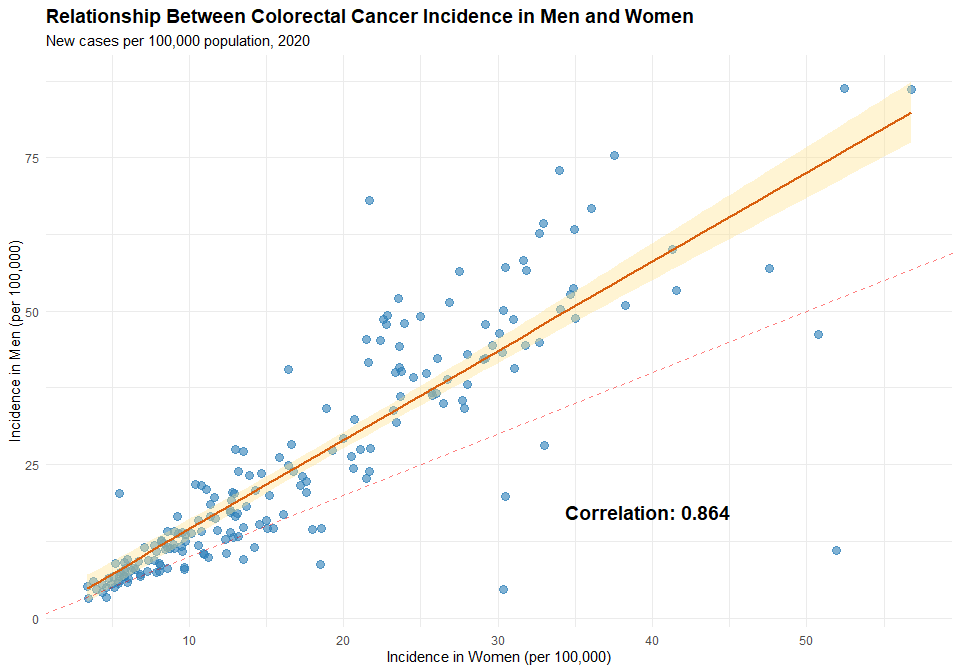

*Note: The dashed red line represents equal incidence rates in both genders. Points above this line indicate higher rates in men, while points below indicate higher rates in women.*

### Top 5 Countries by Incidence Rate

**Men:**

| Country | Cases per 100,000 |
| --- | --- |
| Monaco | 86.27 |
| Netherlands | 86.15 |
| Slovakia | 75.42 |
| Hungary | 72.97 |
| Andorra | 67.97 |

**Women:**

| Country | Cases per 100,000 |
| --- | --- |
| Netherlands | 56.78 |
| Monaco | 52.45 |
| UAE | 51.90 |
| Cuba | 50.74 |
| Barbados | 47.61 |

## Interpretation

The analysis of colorectal cancer incidence rates in 2020 reveals several important patterns:

1. **Strong Positive Correlation**: There is a strong positive correlation (r = 0.864) between male and female colorectal cancer incidence rates across countries. This suggests that risk factors affecting colorectal cancer prevalence are largely shared between genders within a given country.
2. **Higher Rates in Men**: On average, men experience higher colorectal cancer incidence rates (25.6 per 100,000) compared to women (17.6 per 100,000), with a ratio of approximately 1.45:1. This is evident in the scatterplot where most data points lie above the equality line.
3. **Geographic Patterns**: Both maps show that developed countries, particularly in Europe, North America, and parts of Asia (notably South Korea and Japan), tend to have higher incidence rates for both genders. This pattern likely reflects differences in dietary habits, lifestyle factors, screening practices, and aging populations.
4. **Shared Risk Factors**: The strong correlation suggests that country-level factors such as dietary patterns (e.g., red meat consumption, processed foods), obesity rates, physical inactivity, and healthcare access affect both men and women similarly within each country.
5. **Gender Differences**: The consistently higher rates in men may be attributed to biological factors (hormonal differences), lifestyle behaviors (higher rates of smoking and alcohol consumption among men in many countries), and potentially differences in screening uptake or healthcare-seeking behavior.

These findings underscore the importance of implementing comprehensive public health interventions that address modifiable risk factors for colorectal cancer, while also recognizing the need for gender-specific approaches in prevention and screening programs.

## Interaction with AI Tools for Data Analysis (My Personal Experience)

I did interact with both AI tools indicated in the course today. While the results were very similar, the experience wasn’t the same.

**Cursor**

Cursor requires prior knowledge or at least exposure to the tool and somehow to the coding process. The most laborious part of the experience was the setup and the preparation of the tool before starting any analysis. But once launched, the result is really worth it, especially since there’s a margin of freedom in the format of output (png, jpeg, pdf, or just text, etc), but my final opinion Cursor is not that user-friendly, especially for beginners.

**Julius AI**

Julius AI requires prior exposure to the currently used AI tools like ChatGPT, and of course, a normal understanding of data, like any similar tool. The setup was very easy and straightforward, the queries were pretty much intuitive, and the changes were, 95% of the time, satisfactory. The images were generated separately, as well as the full report. I think that choosing Claude as the LLM model is the best option, especially due to its writing ability slightly superior to other models. Julius AI is user-friendly, and for beginners like me, I would highly recommend it.